# Complejidad Computacional Semana 3: **P** versus **NP**, Problemas **NP** intermedios

# Teorema de Cook-Levin

Dados L $∈$ **NP** y una string *x*, construimos *φ*<sub>*x*</sub> tal que *x* ∈ *L* ssi *φ*<sub>*x*</sub> ∈ CNF-SAT.

Idea: Sea M una verificadora de L indiferente y con 2 cintas.

*φ*<sub>*x*</sub> es un "patrón de trazas" de las corridas exitosas de M con input *x* y *u* (*u* certificado de *x*).

- supongamos *x* ∈ *L*  
  → ∃ *u* ∈ {0, 1}<sup>*n*</sup>. *M*(*x*, *u*) = 1  
  → existe una traza que representa la corrida exitosa de *M*(*x*, *u*)  
  → usando *u* y la traza, se puede construir una asignacion *z* tal que *φ*<sub>*x*</sub>(*z*) = 1  
  → *φ*<sub>*x*</sub> ∈ CNF-SAT
- supongamos *φ*<sub>*x*</sub> ∈ CNF-SAT  
  → existe *z*, *φ*<sub>*x*</sub>(*z*) = 1  
  → constuir *u* a partir de *z*  
  → x ∈ *L*
- L ≤ <sub>*p*</sub> CNF-SAT, para cualquier L $∈$ **NP**
- Entonces CNF-SAT es **NP**-difícil
- Entonces CNF-SAT es **NP**-completo

# **3SAT**

- una formula es en 3FNC si es en FNC y cada cláusula tiene como máximo 3 literales
- **3SAT** = {⌊*φ*⌋ ∣ *φ* es en 3FNC y es satisfacible $}$

**CNF-SAT** ≤ <sub>*p*</sub> **3SAT**

Idea: usar regla de la resolución al revés.

# Uso de la **NP** completitud de 3SAT

- Se sospecha que **P** ≠ **NP**, o por lo menos que estar **NP** difícil es una garantia de dificultad aceptada hoy en día
- Teniendo un lenguaje, es más fácil mostrar una reducción desde 3SAT que desde cualquier lenguaje **NP**
- La forma de formulas en FNC-3 es conveniente.

# INDSET es **NP** completo

INDSET = {⌊(*G*, *k*)⌋ ∣ ∃ *S* ⊆ *N*(*G*), ∣*S*∣ ≥ *k*, ∀ *u**v* ∈ *S*, *u**v* ∉ *E*(*G*)}

INDSET $∈$ **NP** porque el certificado es el conjunto *S*.

Mostramos 3SAT ≤ <sub>*p*</sub> INDSET.

Sea *φ* = ⋀ *C*<sub>*i*</sub> una formula en FNC3. Sea *m* el número de cláusulas de *φ*, construimos un grafo *G* tal que ⌊*φ*⌋ ∈ 3*S**A**T* ↔ ⌊(*G*, *m*)⌋ ∈ *I**N**D**S**E**T*.

Cada cláusula *C* de *φ* tiene ≤ 3 literales, entonces hay ≤ 7 asignaciones que la satisfacen.

Construimos para *C* un cluster de 7 nodos, marquamos cada uno con las asignaciones que satisfacen su cluster.

Conectamos dos puntos si pertenecen a clusters distintos y representan asignaciones inconsistentes (ie, 1 variables es asignada a 1 en un nodo y 0 en el otro).

Conectamos entre si todos los puntos de un mismo cluster.

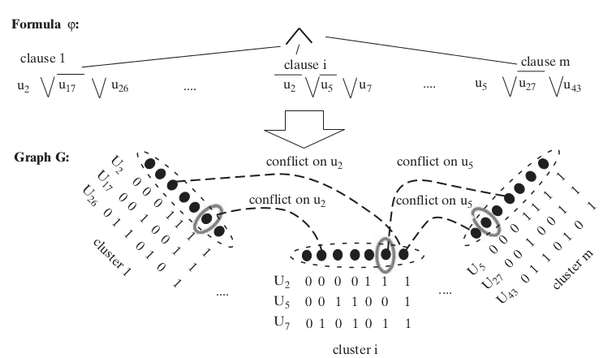

- La transformación se puede hacer en tiempo polinomial.
- *φ* satisfacible  
  → existe asignación *z* tal que *φ*(*z*) = 1  
  → definir *S* los nodos de cada cluster que corresponden a la restriccion de *z* a las variables del cluster  
  → hay *m* nodos no conectados entre si en *G*
- hay *m* nodos no conectados entre si en *G*  
  → pertenecen a clusters distintos  
  → las asignaciones parciales que esos nodos representan son consistentes  
  → con ellas construimos *z* tal que *φ*(*z*) = 1  
  → *φ* satisfacible

# VERTEXCOVER es **NP** completo

Reducción descrita en Sipser, teorema 7.44.

# Búsqueda vs decisión

Supongamos **P** = **NP**. Para todo lenguaje L $∈$ **NP** y una verificadora M para L, existe una MT B corriendo en tiempo polinomial que construye un certificado para todo input *x* ∈ *L*.

Demostración:

- en el caso de SAT: si **NP**=**P**, construir una asignación para *φ* se hace en tiempo polinomial:
  1. probar si *φ* ∈ SAT, seguir si es el caso
  2. probar si *φ*(*x*<sub>1</sub>←0) ∈ SAT, en ese caso fijar el primer bit de *z* a $0$ y reemplazar *x*<sub>1</sub> por 0 en *φ*, en el caso contrario hacer lo mismo con $1$
  3. seguir hasta tener una asignación completa para *φ*
- en el caso general, con L $∈$ **NP**, usar el hecho que la reducción que vimos es una reducción *Levin*, ie, se puede construir un certificado para *x* ∈ *L* a partir del certificado de *φ*<sub>*x*</sub> en tiempo polinomial.

# **P** vs **NP** y **NP** completitud

- 1956: Kurt Gödel escribe una carta a John von Neumann planteándole la posibilidad de decidir en tiempo polinomial si una formula de primer order tiene una prueba de longitud *n*
- 1971: Cook "The Complexity of Theorem Proving Procedures"
- 1972: Karp "Reducibility Among Combinatorial Problems"
- 1972: Miller and Thatcher, editors. "Complexity of computer computations". Plenum Press: proceedings de la conferencia donde se presentó el artículo de Karp frente a 200 investigadores en computación (según el deseo de Michael Rabin)
- 1971/3: Levin "Универсальные задачи перебора" (*Universal search problems*)

# Como manejar problemas **NP**-completos

- Heuristicas: NP es acerca de todos los inputs posibles, mientras que en casos concretos los inputs pueden tener rasgos explotables (simplicidad, simetrías, variables interconectadas, etc.)
- Fijar parametros (parametrized complexity)
- Canjear exactitud por velocidad

# **EXP** vs **NEXP**

**NEXP** = ⋃ <sub>*c* ≥ 0</sub>**NTIME**(2<sup>*n*<sup>*c*</sup></sup>).

Ejercicio: encontrar la definición equivalente con certificados.

Teorema:

**EXP** ≠ **NEXP** implica **P** ≠ **NP**

Supongamos **P**=**NP**. Sea L$∈$**NTIME**(2<sup>*n*<sup>*c*</sup></sup>), y M una MT para *L*.

Entonces si **P**=**NP**, *L*<sub>*p**a**d*</sub> ∈ **P** y existe *M*ʹ deterministica que decide *L*<sub>*p**a**d*</sub>.

Entonces *L* ∈ **EXP**: para decidir si *x* ∈ **L**, lo padeamos con 01<sup>2<sup>∣*x*∣<sup>*c*</sup></sup></sup> y vemos si esto pertenece a *L*<sub>*p**a**d*</sub> usando *M*ʹ.

# El problema de la factorización

Existen problemas naturales que se sospecha estar en **NP** $\$ **P** sin ser **NP** completos.

Factorización:

> Dado *n*, *m* ∈ ℕ tal que 1 ≤ *m* ≤ *n*, ¿ *n* tiene un factor *d* tal que 1 < *d* < *m*?

Se sospecha que FACTOR no está en **P**, ni es **NP** completo ni **coNP** completo.

Observación: el problema ¿ *n* ∈ ℕ es un número compuesto? es una versión relajada de FACTOR y está en **P** (equivalentemente, PRIMES está en **P**).

Otros problemas en **NP**, sospechados de estar en **NP** $\$ (**P** $∪$ **NPC**)

- isomorfirmo de grafos

[figure not shown]

- problema de la autopista con peaje (*turnpike problem*): dadas *n*(*n* − 1) / 2 distancias entre pares de puntos, ¿les corresponde alguna configuración de *n* puntos en una línea?

# Teorema de Ladner

Si **P**≠**NP**, existe un lenguaje en **NP** $\$ **P** que no es **NP** completo.

Idea: definir un problema tal que para ciertos inputs de tamaño *n*, el problema es resolver SAT (para que no este en **P**), y en otros inputs no hacer nada (para que no sea **NP** completo).

# Referencias

- Lipton "The P=NP Question and Gödel’s Lost Letter" (Cap. 1)
- [Unos problemas entre **P** y **NP** completitud](http://cstheory.stackexchange.com/questions/79/problems-between-p-and-npc/237#237)